# PQHS 471 Mid Term

Youjun Li

March 09, 2018

# EDA

## Preparation

```r
load("471midterm.RData")
library(caret)
library(randomForest)
library(skimr)
library(tidyverse)
library(rpart)
library(FactoMineR)
library(gridExtra)
tr=read.csv('census_train.csv', header=T, strip.white=T)
te=read.csv('census_test.csv', header=T, strip.white=T)
```

Trainning and testing datasets are loaded with names called `tr` and `te` respectively.

## Exploratory and Visualization on training set

```r
names(tr)
```

```
##  [1] "age"            "workclass"
##  [3] "fnlwgt"         "education"
##  [5] "education.num"  "marital.status"
##  [7] "occupation"     "relationship"
##  [9] "race"           "sex"
## [11] "capital.gain"   "capital.loss"
## [13] "hours.per.week" "native.country"
## [15] "income"
```

```r
tr=tr[,-c(3,5)]
#missing is coded as "?"
skim(tr)
```

```
## Skim summary statistics
##  n obs: 25000
##  n variables: 13
##
## Variable type: factor
##        variable missing complete     n n_unique
##       education       0    25000 25000       16
##          income       0    25000 25000        2
##  marital.status       0    25000 25000        7
##  native.country       0    25000 25000       42
##      occupation       0    25000 25000       15
##            race       0    25000 25000        5
##    relationship       0    25000 25000        6
##             sex       0    25000 25000        2
##       workclass       0    25000 25000        9
##                                   top_counts
##   HS-: 8064, Som: 5585, Bac: 4105, Mas: 1304
##                 <=5: 19002, >50: 5998, NA: 0
##   Mar: 11493, Nev: 8196, Div: 3425, Sep: 790
##       Uni: 22394, Mex: 501, ?: 437, Phi: 154
##   Pro: 3186, Cra: 3160, Exe: 3146, Adm: 2885
##    Whi: 21370, Bla: 2369, Asi: 806, Ame: 239
##  Hus: 10117, Not: 6370, Own: 3887, Unm: 2626
##                 Mal: 16787, Fem: 8213, NA: 0
##    Pri: 17447, Sel: 1943, Loc: 1606, ?: 1404
##  ordered
##    FALSE
##    FALSE
##    FALSE
##    FALSE
##    FALSE
##    FALSE
##    FALSE
##    FALSE
##    FALSE
##
## Variable type: integer
##        variable missing complete     n    mean
##             age       0    25000 25000   38.6
##    capital.gain       0    25000 25000 1074.33
##    capital.loss       0    25000 25000   88.31
##  hours.per.week       0    25000 25000   40.41
##       sd p0 p25 median p75  p100     hist
##    13.64 17  28     37  48    90 ▇▇▇▆▃▁▁▁
##  7358.75  0   0      0   0 99999 ▇▁▁▁▁▁▁▁
##   404.42  0   0      0   0  4356 ▇▁▁▁▁▁▁▁
##    12.38  1  40     40  45    99 ▁▁▁▇▁▁▁▁
```

Two of the variables got deleted immediately. They are `fnlwgt` and `education.num`. The first one is defined as an estimate of the number of units in the target population that the responding unit represents. Since I will only be focusing on this datset itself rather than trying to generalizing to the US population, it is OK to drop it. The latter is essentially the same as `education`, but with numerical levels that can be ordered. Ordered factor in this case won’t be much of a help, hence, I choose to keep `education`.

From the `skim` function it is easy to see that some of the factor variables have a level of `"?"` which is clearly an indication of missing. I’m replacing it by `NA` for convenience.

```r
tr[,c(2,5,12)]=as.data.frame(apply(tr[,c(2,5,12)], 2, function(x) replace(x, x %in% "?", NA)))
```

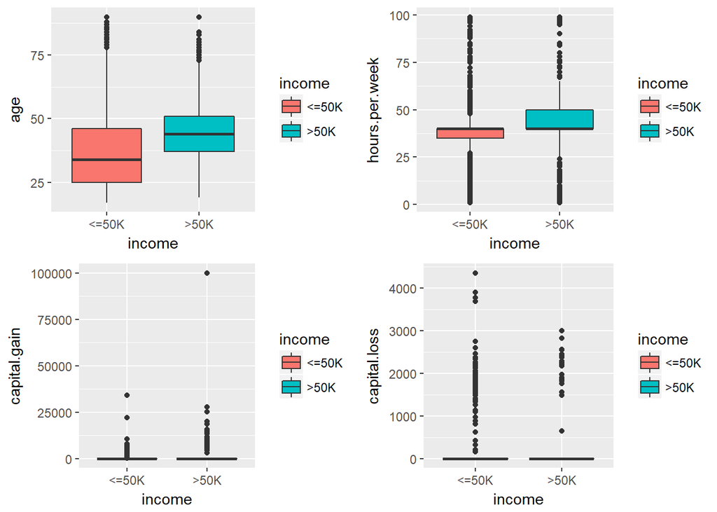

```r
p1=ggplot(tr, aes(x = income, y = age, fill = income)) + geom_boxplot()
p2=ggplot(tr, aes(x = income, y = hours.per.week, fill = income)) + geom_boxplot()
p3=ggplot(tr, aes(x = income, y = capital.gain, fill = income)) + geom_boxplot()
p4=ggplot(tr, aes(x = income, y = capital.loss, fill = income)) + geom_boxplot()
grid.arrange(p1,p2,p3,p4, ncol=2, nrow = 2)
```

## Factor grouping

Some categorical variables have many categories that will cost many degrees of freedom. Moreover, one category can have too few subjects. It is reasonable to group some of the categories.

### Grouping of `workclass`

```r
tr$workclass=fct_recode(tr$workclass,  unemp='Never-worked', unemp='Without-pay', gov='Federal-gov', gov='Local-gov', gov='State-gov')
summary(tr$workclass)
```

```
##              gov            unemp
##             3333               17
##          Private     Self-emp-inc
##            17447              856
## Self-emp-not-inc             NA's
##             1943             1404
```

I grouped subjects that are employed by the government. And since there are very few subjects in `"Never-worked"` and `"without-pay"`, I put them into one level called `"unemp"` for unemployed.

### Grouping of `occupation`

```r
tr$occupation=fct_recode(tr$occupation, skill='Craft-repair', skill='Machine-op-inspct', skill='Protective-serv',
             labor='Farming-fishing', labor='Handlers-cleaners', labor='Priv-house-serv', labor='Transport-moving',
             prof='Adm-clerical', prof='Exec-managerial', prof='Prof-specialty', prof='Sales', prof='Tech-support',
             other='Armed-Forces', other='Other-service')
summary(tr$occupation)
```

```
##  prof other skill labor  NA's
## 12700  2542  5181  3166  1411
```

It got a bit tricky grouping this variable as the categories are very discrete and the appoximate salary level of some categories are very unclear to me, even after googling. So I came up with an idea of grouping by the nature of the job: ones require physical labor, basically anyone can do; ones require special skills that don’t necessarily come with a degree; ones require a certain level of degree to be able to handle; ones that don’t fit into any of the aboves.

### Grouping of `education`

```r
tr$education=fct_recode(tr$education, preHS='Preschool', preHS='10th', preHS='11th', preHS='12th',
                        preHS='1st-4th', preHS='5th-6th', preHS='7th-8th', preHS='9th',
                        assoc='Assoc-acdm', assoc='Assoc-voc')
summary(tr$education)
```

```
##        preHS        assoc    Bachelors
##         3297         1884         4105
##    Doctorate      HS-grad      Masters
##          311         8064         1304
##  Prof-school Some-college
##          450         5585
```

`education` is another variable that has too many levels that could be treated as one, i.e. those elementary levels that don’t play too much of a role in determining how much one makes.

### Grouping of `marital.status`

```r
tr$marital.status=fct_recode(tr$marital.status, married='Married-AF-spouse', married='Married-civ-spouse',
             alone='Married-spouse-absent', alone='Separated', alone='Widowed')
summary(tr$marital.status)
```

```
##      Divorced       married         alone
##          3425         11511          1868
## Never-married
##          8196
```

It is ambiguous how they distinguish people that are married but their spouse doesn’t live in the household and people that live separately with their spouse. Along with the widowed, they all seem to be married but live alone in terms of spouse. So I grouped these people together. I also grouped `"Married-AF-spouse"` and `"Married-civ-spouse"` as there are very few subjects in the former category.

### Grouping of `race`

```r
tr$race=fct_recode(tr$race, minort='Amer-Indian-Eskimo', minort='Other')
summary(tr$race)
```

```
##             minort Asian-Pac-Islander
##                455                806
##              Black              White
##               2369              21370
```

`"Amer-Indian-Eskimo"` and `"Other"` are grouped as minority.

### The use of `relationship`

```r
table(tr$marital.status, tr$relationship)
```

```
##
##                 Husband Not-in-family
##   Divorced            0          1843
##   married         10117            16
##   alone               0           904
##   Never-married       0          3607
##
##                 Other-relative Own-child
##   Divorced                  90       256
##   married                   89        65
##   alone                    110       120
##   Never-married            487      3446
##
##                 Unmarried  Wife
##   Divorced           1236     0
##   married               0  1224
##   alone               734     0
##   Never-married       656     0
```

```r
tr$relationship=fct_recode(tr$relationship, nochild='Husband', nochild='Not-in-family', nochild='Other-relative', nochild='Unmarried', nochild='Wife')
summary(tr$relationship)
```

```
##   nochild Own-child
##     21113      3887
```

The meaning of this variable is not that clear, so I first take a look at the table of it and `"marital.status"`. The table suggests this variable doesn’t really contain much additional information than marital status in the sense that most married people will be in a family and so on. And the categories of `"Husband"` and `"Wife"` look like duplicates of `sex`. The only additional information it has is whether one subject is living with child. So I grouped the ones without child together, making this variable more of a variable for having child or not.

### Removal of `native.country`

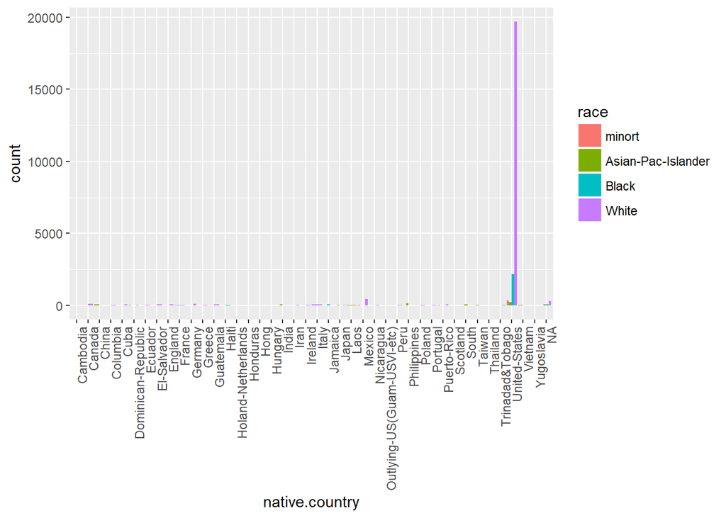

```r
ggplot(tr, aes(x = native.country, y = ..count..)) +
  geom_bar(aes(fill = race), position = "dodge") + theme(axis.text.x = element_text(angle = 90, hjust = 1))
```

```r
#delete country variable
tr=tr[,-12]
```

First of all, this variable has way too many levels and from the plot we can see the majority are from the US. Then if I group the countries by factors like continents, it seems a little redundant as we already have `race`. So I just decided to drop it. Plus it will get rid of some missing values it has.

# Random Forest with training set

## Complete Cases

### Data splitting

```r
#complete cases
trcmp=na.omit(tr)
(nrow(tr)-nrow(trcmp))/nrow(tr)
```

```
## [1] 0.05644
```

```r
#split into training and testing datasets
set.seed(621)
splt.cmp=createDataPartition(trcmp$income,p=0.7,list = F)
#training
trcmp1=trcmp[splt.cmp,]
#testing
trcmp2=trcmp[-splt.cmp,]
```

A little bit more than $5\%$ of the data are missing, that’s not too bad. $70\%$ of the training data will be further partitioned for the model training.

### Random forest with random searching for $m$

```r
#define traincontrol
cntrl=trainControl(method="repeatedcv",number=10, repeats = 5, search="random")

#fit.cmp=train(x=trcmp1[,1:11],y=trcmp1$income, method="rf",trControl=cntrl,tuneLength=10)

print(fit.cmp)
```

```
## Random Forest
##
## 16514 samples
##    11 predictor
##     2 classes: '<=50K', '>50K'
##
## No pre-processing
## Resampling: Cross-Validated (10 fold, repeated 5 times)
## Summary of sample sizes: 14863, 14863, 14862, 14863, 14863, 14862, ...
## Resampling results across tuning parameters:
##
##   mtry  Accuracy   Kappa
##    1    0.8446046  0.5053520
##    2    0.8608334  0.6013258
##    3    0.8595254  0.6040589
##    6    0.8481650  0.5764021
##    7    0.8442894  0.5670224
##    9    0.8411646  0.5594221
##   10    0.8398446  0.5558478
##
## Accuracy was used to select the optimal
##  model using the largest value.
## The final value used for the model was mtry = 2.
```

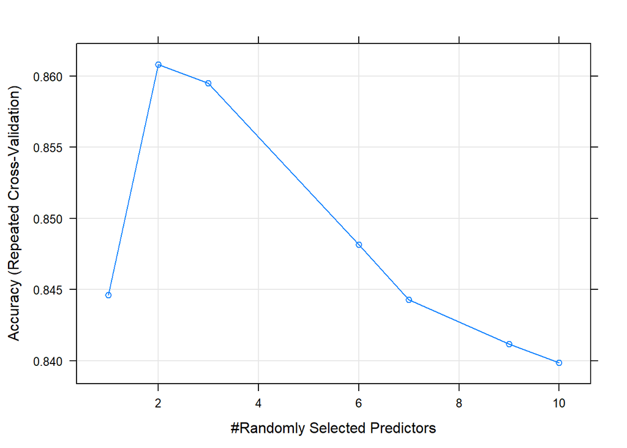

```r
plot(fit.cmp)
```

```r
yhat.cmp=predict(fit.cmp, newdata = trcmp2)
confusionMatrix(data = yhat.cmp, trcmp2$income)
```

```
## Confusion Matrix and Statistics
##
##           Reference
## Prediction <=50K >50K
##      <=50K  4998  627
##      >50K    324 1126
##
##                Accuracy : 0.8656
##                  95% CI : (0.8574, 0.8735)
##     No Information Rate : 0.7522
##     P-Value [Acc > NIR] : < 2.2e-16
##
##                   Kappa : 0.6172
##  Mcnemar's Test P-Value : < 2.2e-16
##
##             Sensitivity : 0.9391
##             Specificity : 0.6423
##          Pos Pred Value : 0.8885
##          Neg Pred Value : 0.7766
##              Prevalence : 0.7522
##          Detection Rate : 0.7064
##    Detection Prevalence : 0.7951
##       Balanced Accuracy : 0.7907
##
##        'Positive' Class : <=50K
##
```

```r
varImp(fit.cmp, scale=FALSE)
```

```
## rf variable importance
##
##                Overall
## marital.status  812.08
## capital.gain    615.78
## education       517.19
## age             452.92
## hours.per.week  281.90
## occupation      241.56
## capital.loss    192.93
## sex             133.38
## workclass       101.91
## relationship     79.22
## race             54.60
```

```r
#mse
mean((as.numeric(yhat.cmp) - as.numeric(trcmp2$income))^2)
```

```
## [1] 0.134417
```

After a 10-fold cross validation repeated five times, $m$ is selected to be $2$ with $0.86$ accuracy. The testing accuracy is $0.866$. The $MSE$ is $0.134$.

## With imputation

### Impute two categorical variables by `rpart`

```r
#impute workclass
imputwkcls=rpart(workclass ~ ., data = tr[!is.na(tr$workclass), ], method = "class")
tr$workclass[is.na(tr$workclass)]=predict(imputwkcls, tr[is.na(tr$workclass), ], type = "class")
summary(tr$workclass)
```

```
##              gov            unemp
##             3333               17
##          Private     Self-emp-inc
##            18851              856
## Self-emp-not-inc
##             1943
```

```r
#impute occupation
imputoccp=rpart(occupation ~ ., data = tr[!is.na(tr$occupation), ], method = "class")
tr$occupation[is.na(tr$occupation)]=predict(imputoccp, tr[is.na(tr$occupation), ], type = "class")
summary(tr$occupation)
```

```
##  prof other skill labor
## 13697  2542  5595  3166
```

### Data splitting

```r
#split data
set.seed(621)
splt.tr=createDataPartition(tr$income,p=0.7,list = F)
#training
tr1=tr[splt.tr,]
#testing
tr2=tr[-splt.tr,]
```

Similar strategy: $70\%$ of the imputed data goes to training.

### Random forest with random searching for $m$

```r
#fit.imp=train(x=tr1[,1:11],y=tr1$income, method="rf",trControl=cntrl, tuneLength=10)

print(fit.imp)
```

```
## Random Forest
##
## 17501 samples
##    11 predictor
##     2 classes: '<=50K', '>50K'
##
## No pre-processing
## Resampling: Cross-Validated (10 fold, repeated 5 times)
## Summary of sample sizes: 15752, 15750, 15750, 15751, 15751, 15751, ...
## Resampling results across tuning parameters:
##
##   mtry  Accuracy   Kappa
##    1    0.8430152  0.4789616
##    3    0.8604997  0.5924788
##    6    0.8483977  0.5656100
##    8    0.8429122  0.5515158
##    9    0.8419180  0.5492251
##   10    0.8406837  0.5462127
##
## Accuracy was used to select the optimal
##  model using the largest value.
## The final value used for the model was mtry = 3.
```

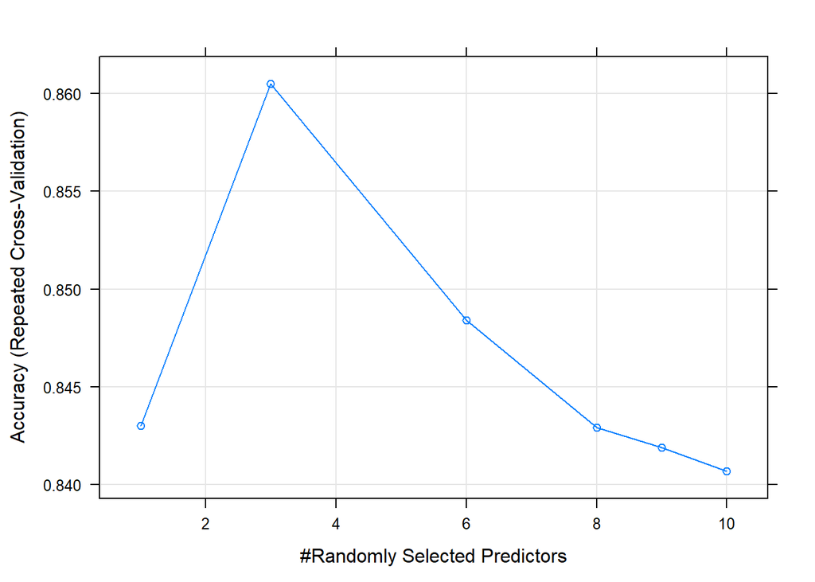

```r
plot(fit.imp)
```

```r
yhat.imp=predict(fit.imp, newdata = tr2)
confusionMatrix(data = yhat.imp, tr2$income)
```

```
## Confusion Matrix and Statistics
##
##           Reference
## Prediction <=50K >50K
##      <=50K  5363  624
##      >50K    337 1175
##
##                Accuracy : 0.8718
##                  95% CI : (0.8641, 0.8793)
##     No Information Rate : 0.7601
##     P-Value [Acc > NIR] : < 2.2e-16
##
##                   Kappa : 0.6283
##  Mcnemar's Test P-Value : < 2.2e-16
##
##             Sensitivity : 0.9409
##             Specificity : 0.6531
##          Pos Pred Value : 0.8958
##          Neg Pred Value : 0.7771
##              Prevalence : 0.7601
##          Detection Rate : 0.7152
##    Detection Prevalence : 0.7984
##       Balanced Accuracy : 0.7970
##
##        'Positive' Class : <=50K
##
```

```r
varImp(fit.imp, scale=FALSE)
```

```
## rf variable importance
##
##                Overall
## marital.status  977.88
## capital.gain    728.87
## age             695.50
## education       646.25
## hours.per.week  437.16
## occupation      264.54
## capital.loss    222.77
## workclass       160.73
## sex             109.04
## race             93.34
## relationship     60.04
```

```r
#mse
mean((as.numeric(yhat.imp) - as.numeric(tr2$income))^2)
```

```
## [1] 0.1281504
```

After a 10-fold cross validation repeated five times, $m$ is selected to be $3$ with $0.86$ accuracy. The testing accuracy is $0.872$. The $MSE$ is $0.128$. It looks like there is a minor improvement with imputation. However, the difference is too small, not significant enough for me rule one out. So I will use both complete and imputed models to predict the final testing set and compare.

# Random Forest with testing set

## Same procedure as the training set

```r
te=read.csv('census_test.csv', header=T, strip.white=T)
#delete sample weights and education level
te=te[,-c(3,5)]
#missing is coded as "?"
skim(te)
```

```
## Skim summary statistics
##  n obs: 7561
##  n variables: 13
##
## Variable type: factor
##        variable missing complete    n n_unique
##       education       0     7561 7561       16
##          income       0     7561 7561        2
##  marital.status       0     7561 7561        7
##  native.country       0     7561 7561       41
##      occupation       0     7561 7561       15
##            race       0     7561 7561        5
##    relationship       0     7561 7561        6
##             sex       0     7561 7561        2
##       workclass       0     7561 7561        8
##                                 top_counts
##  HS-: 2437, Som: 1706, Bac: 1250, Mas: 419
##                <=5: 5718, >50: 1843, NA: 0
##  Mar: 3483, Nev: 2487, Div: 1018, Wid: 242
##       Uni: 6776, ?: 146, Mex: 142, Phi: 44
##     Pro: 954, Cra: 939, Exe: 920, Adm: 885
##     Whi: 6446, Bla: 755, Asi: 233, Ame: 72
##  Hus: 3076, Not: 1935, Own: 1181, Unm: 820
##                Mal: 5003, Fem: 2558, NA: 0
##      Pri: 5249, Sel: 598, Loc: 487, ?: 432
##  ordered
##    FALSE
##    FALSE
##    FALSE
##    FALSE
##    FALSE
##    FALSE
##    FALSE
##    FALSE
##    FALSE
##
## Variable type: integer
##        variable missing complete    n    mean
##             age       0     7561 7561   38.53
##    capital.gain       0     7561 7561 1088.62
##    capital.loss       0     7561 7561   83.97
##  hours.per.week       0     7561 7561   40.53
##       sd p0 p25 median p75  p100     hist
##    13.63 17  28     37  47    90 ▇▇▇▆▃▂▁▁
##  7472.86  0   0      0   0 99999 ▇▁▁▁▁▁▁▁
##   398.11  0   0      0   0  4356 ▇▁▁▁▁▁▁▁
##    12.26  1  40     40  45    99 ▁▁▁▇▁▁▁▁
```

```r
#change "?" to NA
te[,c(2,5,12)]=as.data.frame(apply(te[,c(2,5,12)], 2, function(x) replace(x, x %in% "?", NA)))

#goup some factors that have multiple levels
#workclass
te$workclass=fct_recode(te$workclass,  unemp='Never-worked', unemp='Without-pay', gov='Federal-gov', gov='Local-gov', gov='State-gov')
summary(te$workclass)
```

```
##              gov          Private
##             1018             5249
##     Self-emp-inc Self-emp-not-inc
##              260              598
##            unemp             NA's
##                4              432
```

```r
#occupation
te$occupation=fct_recode(te$occupation, skill='Craft-repair', skill='Machine-op-inspct', skill='Protective-serv',
                         labor='Farming-fishing', labor='Handlers-cleaners', labor='Priv-house-serv', labor='Transport-moving',
                         prof='Adm-clerical', prof='Exec-managerial', prof='Prof-specialty', prof='Sales', prof='Tech-support',
                         other='Armed-Forces', other='Other-service')
summary(te$occupation)
```

```
##  prof other skill labor  NA's
##  3854   762  1569   944   432
```

```r
#education
te$education=fct_recode(te$education, preHS='Preschool', preHS='10th', preHS='11th', preHS='12th',
                        preHS='1st-4th', preHS='5th-6th', preHS='7th-8th', preHS='9th',
                        assoc='Assoc-acdm', assoc='Assoc-voc')
summary(te$education)
```

```
##        preHS        assoc    Bachelors
##          956          565         1250
##    Doctorate      HS-grad      Masters
##          102         2437          419
##  Prof-school Some-college
##          126         1706
```

```r
#marital status
te$marital.status=fct_recode(te$marital.status, married='Married-AF-spouse', married='Married-civ-spouse',
                             alone='Married-spouse-absent', alone='Separated', alone='Widowed')
summary(te$marital.status)
```

```
##      Divorced       married         alone
##          1018          3488           568
## Never-married
##          2487
```

```r
#race
te$race=fct_recode(te$race, minort='Amer-Indian-Eskimo', minort='Other')
summary(te$race)
```

```
##             minort Asian-Pac-Islander
##                127                233
##              Black              White
##                755               6446
```

```r
#relationship
table(te$marital.status, te$relationship)
```

```
##
##                 Husband Not-in-family
##   Divorced            0           561
##   married          3076             1
##   alone               0           274
##   Never-married       0          1099
##
##                 Other-relative Own-child
##   Divorced                  20        72
##   married                   36        31
##   alone                     25        39
##   Never-married            124      1039
##
##                 Unmarried Wife
##   Divorced            365    0
##   married               0  344
##   alone               230    0
##   Never-married       225    0
```

```r
te$relationship=fct_recode(te$relationship, nochild='Husband', nochild='Not-in-family', nochild='Other-relative', nochild='Unmarried', nochild='Wife')
summary(te$relationship)
```

```
##   nochild Own-child
##      6380      1181
```

```r
#delete country variable
te=te[,-12]
#complete cases
tecmp=na.omit(te)
(nrow(te)-nrow(tecmp))/nrow(te)
```

```
## [1] 0.0571353
```

Grouping for each variable is the same. And I only keep the comlete cases since I consider this testing set a new dataset that comes later on.

## Test with complete cases model

```r
yhat.cmp.new=predict(fit.cmp, newdata = tecmp)
confusionMatrix(data = yhat.cmp.new, tecmp$income)
```

```
## Confusion Matrix and Statistics
##
##           Reference
## Prediction <=50K >50K
##      <=50K  5080  819
##      >50K    245  985
##
##                Accuracy : 0.8508
##                  95% CI : (0.8423, 0.8589)
##     No Information Rate : 0.7469
##     P-Value [Acc > NIR] : < 2.2e-16
##
##                   Kappa : 0.5588
##  Mcnemar's Test P-Value : < 2.2e-16
##
##             Sensitivity : 0.9540
##             Specificity : 0.5460
##          Pos Pred Value : 0.8612
##          Neg Pred Value : 0.8008
##              Prevalence : 0.7469
##          Detection Rate : 0.7126
##    Detection Prevalence : 0.8275
##       Balanced Accuracy : 0.7500
##
##        'Positive' Class : <=50K
##
```

```r
#mse
mean((as.numeric(yhat.cmp.new) - as.numeric(tecmp$income))^2)
```

```
## [1] 0.1492495
```

The accuracy is $0.851$ and the $MSE$ is $0.149$.

## Test with imputed model

```r
yhat.imp.new=predict(fit.imp, newdata = tecmp)
confusionMatrix(data = yhat.imp.new, tecmp$income)
```

```
## Confusion Matrix and Statistics
##
##           Reference
## Prediction <=50K >50K
##      <=50K  5067  832
##      >50K    258  972
##
##                Accuracy : 0.8471
##                  95% CI : (0.8385, 0.8554)
##     No Information Rate : 0.7469
##     P-Value [Acc > NIR] : < 2.2e-16
##
##                   Kappa : 0.548
##  Mcnemar's Test P-Value : < 2.2e-16
##
##             Sensitivity : 0.9515
##             Specificity : 0.5388
##          Pos Pred Value : 0.8590
##          Neg Pred Value : 0.7902
##              Prevalence : 0.7469
##          Detection Rate : 0.7108
##    Detection Prevalence : 0.8275
##       Balanced Accuracy : 0.7452
##
##        'Positive' Class : <=50K
##
```

```r
#mse
mean((as.numeric(yhat.imp.new) - as.numeric(tecmp$income))^2)
```

```
## [1] 0.1528966
```

The accuracy is $0.847$ and the $MSE$ is $0.153$.

The results are still very close, but this time the complete cases model performed slightly better. In this case where the missing only takes a small portion of the whole dataset, I’d prefer using complete cases as imputation for factors is never a good strategy.

# Repeated Analysis without Aggressive Grouping

When I look at the importance of the variables, there are things I didn’t expect: for both complete and imputed, the first variable is marital status, which I thought would go lower rank. And occupation has never been on the top, which is weird as what job you have probably decides how much you make. So I started wondering if it is my grouping strategy that distorted the effects of these variables. After all, I did use a very aggressive strategy on some variables, especially on `occupation`. It seems to me that the only way to varify this is to repeat the random forest without gourping occupation and marital status.

For simplicity of the report, I will only provide the results here, and the code will be in the script file. For both complete and imputed methods, the results without aggressive grouping turn out to be a bit Worse. More precisely, with the complete method, the final test accuracy is $0.847$ and $MSE$ is $0.153$; with the imputed method, the final test accuracy is $0.845$ and $MSE$ is $0.155$.

Additionally, I have also tried logistic regression and it didn’t out-perform random forest, although it came very close. Considering the time that random forest took, logistic regression might be a good option for preliminary analysis to grasp the basic idea of the data.